# Wrangle Act

## Project: Wrangling and Analyze Data

### Directly download the WeRateDogs Twitter archive data (twitter_archive_enhanced.csv)

```python
import pandas as pd
df = pd.read_csv(r"C:\Users\muazh\OneDrive\Documents\twitter\twitter-archive-enhanced (1).csv")
df.head(3)
```

|  | tweet_id | in_reply_to_status_id | in_reply_to_user_id | timestamp | source | text | retweeted_status_id | retweeted_status_user_id | retweeted_status_timestamp | expanded_urls | rating_numerator | rating_denominator | name | doggo | floofer | pupper | puppo |
| --- | --- | --- | --- | --- | --- | --- | --- | --- | --- | --- | --- | --- | --- | --- | --- | --- | --- |
| 0 | 892420643555336193 | NaN | NaN | 2017-08-01 16:23:56 +0000 | <a href="http://twitter.com/download/iphone" r... | This is Phineas. He's a mystical boy. Only eve... | NaN | NaN | NaN | https://twitter.com/dog_rates/status/892420643... | 13 | 10 | Phineas | None | None | None | None |
| 1 | 892177421306343426 | NaN | NaN | 2017-08-01 00:17:27 +0000 | <a href="http://twitter.com/download/iphone" r... | This is Tilly. She's just checking pup on you.... | NaN | NaN | NaN | https://twitter.com/dog_rates/status/892177421... | 13 | 10 | Tilly | None | None | None | None |
| 2 | 891815181378084864 | NaN | NaN | 2017-07-31 00:18:03 +0000 | <a href="http://twitter.com/download/iphone" r... | This is Archie. He is a rare Norwegian Pouncin... | NaN | NaN | NaN | https://twitter.com/dog_rates/status/891815181... | 12 | 10 | Archie | None | None | None | None |

### Use the Requests library to download the tweet image prediction (image_predictions.tsv)

```python
import os
import pandas as pd
import requests
from bs4 import BeautifulSoup


import requests
url = 'https://d17h27t6h515a5.cloudfront.net/topher/2017/August/599fd2ad_image-predictions/image-predictions.tsv'
request_images = requests.get(url)

# Save tsv to a file
with open("image-predictions.tsv", mode='wb') as file:
    file.write(request_images.content)
```

```python
df2 = pd.read_csv('image-predictions.tsv', sep='\t')
df2.head(5)
```

|  | tweet_id | jpg_url | img_num | p1 | p1_conf | p1_dog | p2 | p2_conf | p2_dog | p3 | p3_conf | p3_dog |
| --- | --- | --- | --- | --- | --- | --- | --- | --- | --- | --- | --- | --- |
| 0 | 666020888022790149 | https://pbs.twimg.com/media/CT4udn0WwAA0aMy.jpg | 1 | Welsh_springer_spaniel | 0.465074 | True | collie | 0.156665 | True | Shetland_sheepdog | 0.061428 | True |
| 1 | 666029285002620928 | https://pbs.twimg.com/media/CT42GRgUYAA5iDo.jpg | 1 | redbone | 0.506826 | True | miniature_pinscher | 0.074192 | True | Rhodesian_ridgeback | 0.072010 | True |
| 2 | 666033412701032449 | https://pbs.twimg.com/media/CT4521TWwAEvMyu.jpg | 1 | German_shepherd | 0.596461 | True | malinois | 0.138584 | True | bloodhound | 0.116197 | True |
| 3 | 666044226329800704 | https://pbs.twimg.com/media/CT5Dr8HUEAA-lEu.jpg | 1 | Rhodesian_ridgeback | 0.408143 | True | redbone | 0.360687 | True | miniature_pinscher | 0.222752 | True |
| 4 | 666049248165822465 | https://pbs.twimg.com/media/CT5IQmsXIAAKY4A.jpg | 1 | miniature_pinscher | 0.560311 | True | Rottweiler | 0.243682 | True | Doberman | 0.154629 | True |

### Use the Tweepy library to query additional data via the Twitter API (tweet_json.txt)

```python
import tweepy as tw

consumer_key = 'Insert your key'
consumer_secret = 'Insert your key'
access_token = 'Insert your key'
access_secret = 'Insert your key'

auth = tw.OAuthHandler(consumer_key, consumer_secret)
auth.set_access_token(access_token, access_secret)

api = tw.API(auth)
```

```python
#METHOD 2 TO GET TWITTER DATA
with open("tweet-json.txt", "r", encoding="utf-8") as json_file:
    for tweet_id in json_file:
        try:
            tweet = api.get_status(tweet_id, tweet_mode="extended")
            json.dump(data._json, json_file)
            json_file.write("\n")
        except:
                continue
```

```python
import json
columns_header = ["tweet_id", "favorite_count", "retweet_count"]
df_list = []
for json_string in open("tweet-json.txt", "r"):
    tweet = json.loads(json_string)
    df_list.append({
        "tweet_id": tweet["id"],
        "favorite_count": tweet["favorite_count"],
        "retweet_count": tweet["retweet_count"]
    })
```

```python
df3 = pd.DataFrame(df_list, columns=columns_header)
df3.head()
```

|  | tweet_id | favorite_count | retweet_count |
| --- | --- | --- | --- |
| 0 | 892420643555336193 | 39467 | 8853 |
| 1 | 892177421306343426 | 33819 | 6514 |
| 2 | 891815181378084864 | 25461 | 4328 |
| 3 | 891689557279858688 | 42908 | 8964 |
| 4 | 891327558926688256 | 41048 | 9774 |

```python
#METHOD ONE FOR TWITTER DATA WITHOUT THE API
import json
import pandas as pd
df_list = []
with open("tweet-json.txt", 'r') as json_file:
    for tweet_id in json_file:
        load_tweet = json.loads(tweet_id)

        tweet_id = load_tweet ["id"]
        favorite_count = load_tweet ["favorite_count"]
        retweet_count = load_tweet ["retweet_count"]

        df_list.append({'tweet_id': tweet_id,
                        'retweet_count': retweet_count,
                        'favorite_count': favorite_count})

df4 = pd.DataFrame(df_list, columns = ["tweet_id","retweet_count","favorite_count"])
df4
```

|  | tweet_id | retweet_count | favorite_count |
| --- | --- | --- | --- |
| 0 | 892420643555336193 | 8853 | 39467 |
| 1 | 892177421306343426 | 6514 | 33819 |
| 2 | 891815181378084864 | 4328 | 25461 |
| 3 | 891689557279858688 | 8964 | 42908 |
| 4 | 891327558926688256 | 9774 | 41048 |
| ... | ... | ... | ... |
| 2349 | 666049248165822465 | 41 | 111 |
| 2350 | 666044226329800704 | 147 | 311 |
| 2351 | 666033412701032449 | 47 | 128 |
| 2352 | 666029285002620928 | 48 | 132 |
| 2353 | 666020888022790149 | 532 | 2535 |

2354 rows × 3 columns

```python
df4['retweet_count'] = df4['retweet_count'].astype(int)
df4['favorite_count'] = df4['favorite_count'].astype(int)
```

```python
#making copy of each data set to check quality issues and tirediness before cleaning
df10_clean = df.copy()
df2_clean = df2.copy()
df4_clean = df4.copy()
```

```python
df10_clean
```

|  | tweet_id | in_reply_to_status_id | in_reply_to_user_id | timestamp | source | text | retweeted_status_id | retweeted_status_user_id | retweeted_status_timestamp | expanded_urls | rating_numerator | rating_denominator | name | doggo | floofer | pupper | puppo |
| --- | --- | --- | --- | --- | --- | --- | --- | --- | --- | --- | --- | --- | --- | --- | --- | --- | --- |
| 0 | 892420643555336193 | NaN | NaN | 2017-08-01 16:23:56 +0000 | <a href="http://twitter.com/download/iphone" r... | This is Phineas. He's a mystical boy. Only eve... | NaN | NaN | NaN | https://twitter.com/dog_rates/status/892420643... | 13 | 10 | Phineas | None | None | None | None |
| 1 | 892177421306343426 | NaN | NaN | 2017-08-01 00:17:27 +0000 | <a href="http://twitter.com/download/iphone" r... | This is Tilly. She's just checking pup on you.... | NaN | NaN | NaN | https://twitter.com/dog_rates/status/892177421... | 13 | 10 | Tilly | None | None | None | None |
| 2 | 891815181378084864 | NaN | NaN | 2017-07-31 00:18:03 +0000 | <a href="http://twitter.com/download/iphone" r... | This is Archie. He is a rare Norwegian Pouncin... | NaN | NaN | NaN | https://twitter.com/dog_rates/status/891815181... | 12 | 10 | Archie | None | None | None | None |
| 3 | 891689557279858688 | NaN | NaN | 2017-07-30 15:58:51 +0000 | <a href="http://twitter.com/download/iphone" r... | This is Darla. She commenced a snooze mid meal... | NaN | NaN | NaN | https://twitter.com/dog_rates/status/891689557... | 13 | 10 | Darla | None | None | None | None |
| 4 | 891327558926688256 | NaN | NaN | 2017-07-29 16:00:24 +0000 | <a href="http://twitter.com/download/iphone" r... | This is Franklin. He would like you to stop ca... | NaN | NaN | NaN | https://twitter.com/dog_rates/status/891327558... | 12 | 10 | Franklin | None | None | None | None |
| ... | ... | ... | ... | ... | ... | ... | ... | ... | ... | ... | ... | ... | ... | ... | ... | ... | ... |
| 2351 | 666049248165822465 | NaN | NaN | 2015-11-16 00:24:50 +0000 | <a href="http://twitter.com/download/iphone" r... | Here we have a 1949 1st generation vulpix. Enj... | NaN | NaN | NaN | https://twitter.com/dog_rates/status/666049248... | 5 | 10 | None | None | None | None | None |
| 2352 | 666044226329800704 | NaN | NaN | 2015-11-16 00:04:52 +0000 | <a href="http://twitter.com/download/iphone" r... | This is a purebred Piers Morgan. Loves to Netf... | NaN | NaN | NaN | https://twitter.com/dog_rates/status/666044226... | 6 | 10 | a | None | None | None | None |
| 2353 | 666033412701032449 | NaN | NaN | 2015-11-15 23:21:54 +0000 | <a href="http://twitter.com/download/iphone" r... | Here is a very happy pup. Big fan of well-main... | NaN | NaN | NaN | https://twitter.com/dog_rates/status/666033412... | 9 | 10 | a | None | None | None | None |
| 2354 | 666029285002620928 | NaN | NaN | 2015-11-15 23:05:30 +0000 | <a href="http://twitter.com/download/iphone" r... | This is a western brown Mitsubishi terrier. Up... | NaN | NaN | NaN | https://twitter.com/dog_rates/status/666029285... | 7 | 10 | a | None | None | None | None |
| 2355 | 666020888022790149 | NaN | NaN | 2015-11-15 22:32:08 +0000 | <a href="http://twitter.com/download/iphone" r... | Here we have a Japanese Irish Setter. Lost eye... | NaN | NaN | NaN | https://twitter.com/dog_rates/status/666020888... | 8 | 10 | None | None | None | None | None |

2356 rows × 17 columns

```python
df10_clean.info()
```

```
<class 'pandas.core.frame.DataFrame'>
RangeIndex: 2356 entries, 0 to 2355
Data columns (total 17 columns):
 #   Column                      Non-Null Count  Dtype
---  ------                      --------------  -----
 0   tweet_id                    2356 non-null   int64
 1   in_reply_to_status_id       78 non-null     float64
 2   in_reply_to_user_id         78 non-null     float64
 3   timestamp                   2356 non-null   object
 4   source                      2356 non-null   object
 5   text                        2356 non-null   object
 6   retweeted_status_id         181 non-null    float64
 7   retweeted_status_user_id    181 non-null    float64
 8   retweeted_status_timestamp  181 non-null    object
 9   expanded_urls               2297 non-null   object
 10  rating_numerator            2356 non-null   int64
 11  rating_denominator          2356 non-null   int64
 12  name                        2356 non-null   object
 13  doggo                       2356 non-null   object
 14  floofer                     2356 non-null   object
 15  pupper                      2356 non-null   object
 16  puppo                       2356 non-null   object
dtypes: float64(4), int64(3), object(10)
memory usage: 313.0+ KB
```

```python
df2_clean
```

|  | tweet_id | jpg_url | img_num | p1 | p1_conf | p1_dog | p2 | p2_conf | p2_dog | p3 | p3_conf | p3_dog |
| --- | --- | --- | --- | --- | --- | --- | --- | --- | --- | --- | --- | --- |
| 0 | 666020888022790149 | https://pbs.twimg.com/media/CT4udn0WwAA0aMy.jpg | 1 | Welsh_springer_spaniel | 0.465074 | True | collie | 0.156665 | True | Shetland_sheepdog | 0.061428 | True |
| 1 | 666029285002620928 | https://pbs.twimg.com/media/CT42GRgUYAA5iDo.jpg | 1 | redbone | 0.506826 | True | miniature_pinscher | 0.074192 | True | Rhodesian_ridgeback | 0.072010 | True |
| 2 | 666033412701032449 | https://pbs.twimg.com/media/CT4521TWwAEvMyu.jpg | 1 | German_shepherd | 0.596461 | True | malinois | 0.138584 | True | bloodhound | 0.116197 | True |
| 3 | 666044226329800704 | https://pbs.twimg.com/media/CT5Dr8HUEAA-lEu.jpg | 1 | Rhodesian_ridgeback | 0.408143 | True | redbone | 0.360687 | True | miniature_pinscher | 0.222752 | True |
| 4 | 666049248165822465 | https://pbs.twimg.com/media/CT5IQmsXIAAKY4A.jpg | 1 | miniature_pinscher | 0.560311 | True | Rottweiler | 0.243682 | True | Doberman | 0.154629 | True |
| ... | ... | ... | ... | ... | ... | ... | ... | ... | ... | ... | ... | ... |
| 2070 | 891327558926688256 | https://pbs.twimg.com/media/DF6hr6BUMAAzZgT.jpg | 2 | basset | 0.555712 | True | English_springer | 0.225770 | True | German_short-haired_pointer | 0.175219 | True |
| 2071 | 891689557279858688 | https://pbs.twimg.com/media/DF_q7IAWsAEuuN8.jpg | 1 | paper_towel | 0.170278 | False | Labrador_retriever | 0.168086 | True | spatula | 0.040836 | False |
| 2072 | 891815181378084864 | https://pbs.twimg.com/media/DGBdLU1WsAANxJ9.jpg | 1 | Chihuahua | 0.716012 | True | malamute | 0.078253 | True | kelpie | 0.031379 | True |
| 2073 | 892177421306343426 | https://pbs.twimg.com/media/DGGmoV4XsAAUL6n.jpg | 1 | Chihuahua | 0.323581 | True | Pekinese | 0.090647 | True | papillon | 0.068957 | True |
| 2074 | 892420643555336193 | https://pbs.twimg.com/media/DGKD1-bXoAAIAUK.jpg | 1 | orange | 0.097049 | False | bagel | 0.085851 | False | banana | 0.076110 | False |

2075 rows × 12 columns

```python
df2_clean.describe()
```

|  | tweet_id | img_num | p1_conf | p2_conf | p3_conf |
| --- | --- | --- | --- | --- | --- |
| count | 2.075000e+03 | 2075.000000 | 2075.000000 | 2.075000e+03 | 2.075000e+03 |
| mean | 7.384514e+17 | 1.203855 | 0.594548 | 1.345886e-01 | 6.032417e-02 |
| std | 6.785203e+16 | 0.561875 | 0.271174 | 1.006657e-01 | 5.090593e-02 |
| min | 6.660209e+17 | 1.000000 | 0.044333 | 1.011300e-08 | 1.740170e-10 |
| 25% | 6.764835e+17 | 1.000000 | 0.364412 | 5.388625e-02 | 1.622240e-02 |
| 50% | 7.119988e+17 | 1.000000 | 0.588230 | 1.181810e-01 | 4.944380e-02 |
| 75% | 7.932034e+17 | 1.000000 | 0.843855 | 1.955655e-01 | 9.180755e-02 |
| max | 8.924206e+17 | 4.000000 | 1.000000 | 4.880140e-01 | 2.734190e-01 |

```python
df2_clean.info()
```

```
<class 'pandas.core.frame.DataFrame'>
RangeIndex: 2075 entries, 0 to 2074
Data columns (total 12 columns):
 #   Column    Non-Null Count  Dtype
---  ------    --------------  -----
 0   tweet_id  2075 non-null   int64
 1   jpg_url   2075 non-null   object
 2   img_num   2075 non-null   int64
 3   p1        2075 non-null   object
 4   p1_conf   2075 non-null   float64
 5   p1_dog    2075 non-null   bool
 6   p2        2075 non-null   object
 7   p2_conf   2075 non-null   float64
 8   p2_dog    2075 non-null   bool
 9   p3        2075 non-null   object
 10  p3_conf   2075 non-null   float64
 11  p3_dog    2075 non-null   bool
dtypes: bool(3), float64(3), int64(2), object(4)
memory usage: 152.1+ KB
```

```python
df4_clean.info()
```

```
<class 'pandas.core.frame.DataFrame'>
RangeIndex: 2354 entries, 0 to 2353
Data columns (total 3 columns):
 #   Column          Non-Null Count  Dtype
---  ------          --------------  -----
 0   tweet_id        2354 non-null   int64
 1   retweet_count   2354 non-null   int32
 2   favorite_count  2354 non-null   int32
dtypes: int32(2), int64(1)
memory usage: 36.9 KB
```

### Quality Issues

twitter archive

1.converting timestamp to datetime

2.columns such as retweeted_status_id, retweeted_status_user_id , in_reply_to_user_id, retweeted_status_timestamp should be dropped

3.The column name contains None and a values

image-predictions

7.columns such as p1, p2, and p3 have their names not consistent such as small letters and capital letters

8.under score should be removed from p1,p2 and p3 columns.

9.Removing HTML Tags from the source columns to get the actual source people tweet from

### Tirediness Issues

1.Merge all three datasets together (twitter archive , image-predictions, additional data)

2.extract years and months from the timestamp columns after converting to datetime

3.Dog stages doggo, floofer, pupper, puppo should be merge into one

### Define

###### converting timestamp to datetime

##### Code

```python
df10_clean['timestamp'] = pd.to_datetime(df10_clean['timestamp'])
```

### Test

```python
df10_clean.info()
```

```
<class 'pandas.core.frame.DataFrame'>
RangeIndex: 2356 entries, 0 to 2355
Data columns (total 17 columns):
 #   Column                      Non-Null Count  Dtype
---  ------                      --------------  -----
 0   tweet_id                    2356 non-null   int64
 1   in_reply_to_status_id       78 non-null     float64
 2   in_reply_to_user_id         78 non-null     float64
 3   timestamp                   2356 non-null   datetime64[ns, UTC]
 4   source                      2356 non-null   object
 5   text                        2356 non-null   object
 6   retweeted_status_id         181 non-null    float64
 7   retweeted_status_user_id    181 non-null    float64
 8   retweeted_status_timestamp  181 non-null    object
 9   expanded_urls               2297 non-null   object
 10  rating_numerator            2356 non-null   int64
 11  rating_denominator          2356 non-null   int64
 12  name                        2356 non-null   object
 13  doggo                       2356 non-null   object
 14  floofer                     2356 non-null   object
 15  pupper                      2356 non-null   object
 16  puppo                       2356 non-null   object
dtypes: datetime64[ns, UTC](1), float64(4), int64(3), object(9)
memory usage: 313.0+ KB
```

### Define

##### Droping of irrelevant columns (retweeted_status_id, retweeted_status_user_id , in_reply_to_user_id, retweeted_status_timestamp)

### Code

```python
df10_clean.drop(['in_reply_to_status_id','in_reply_to_user_id', 'retweeted_status_timestamp',
               'retweeted_status_id','retweeted_status_user_id'], axis = 1, inplace = True)
```

### Test

```python
df10_clean.head()
```

|  | tweet_id | timestamp | source | text | expanded_urls | rating_numerator | rating_denominator | name | doggo | floofer | pupper | puppo |
| --- | --- | --- | --- | --- | --- | --- | --- | --- | --- | --- | --- | --- |
| 0 | 892420643555336193 | 2017-08-01 16:23:56+00:00 | <a href="http://twitter.com/download/iphone" r... | This is Phineas. He's a mystical boy. Only eve... | https://twitter.com/dog_rates/status/892420643... | 13 | 10 | Phineas | None | None | None | None |
| 1 | 892177421306343426 | 2017-08-01 00:17:27+00:00 | <a href="http://twitter.com/download/iphone" r... | This is Tilly. She's just checking pup on you.... | https://twitter.com/dog_rates/status/892177421... | 13 | 10 | Tilly | None | None | None | None |
| 2 | 891815181378084864 | 2017-07-31 00:18:03+00:00 | <a href="http://twitter.com/download/iphone" r... | This is Archie. He is a rare Norwegian Pouncin... | https://twitter.com/dog_rates/status/891815181... | 12 | 10 | Archie | None | None | None | None |
| 3 | 891689557279858688 | 2017-07-30 15:58:51+00:00 | <a href="http://twitter.com/download/iphone" r... | This is Darla. She commenced a snooze mid meal... | https://twitter.com/dog_rates/status/891689557... | 13 | 10 | Darla | None | None | None | None |
| 4 | 891327558926688256 | 2017-07-29 16:00:24+00:00 | <a href="http://twitter.com/download/iphone" r... | This is Franklin. He would like you to stop ca... | https://twitter.com/dog_rates/status/891327558... | 12 | 10 | Franklin | None | None | None | None |

### Define

##### Replacing NONE and A values in Name column with NAN

### Code

```python
# Writing a function to loop through the nme columns and replace wromg_name with NaN
import numpy as np
def replace_name(value):
    wrong_name = ('a','None','the','an','O')
    if value in wrong_name:
        return np.nan
    else:
        return value

df10_clean['name'] = df10_clean['name'].apply(lambda x:replace_name(x))
```

### Test

```python
df10_clean['name']
```

```
0        Phineas
1          Tilly
2         Archie
3          Darla
4       Franklin
          ...
2351         NaN
2352         NaN
2353         NaN
2354         NaN
2355         NaN
Name: name, Length: 2356, dtype: object
```

### Define

##### columns such as p1, p2, and p3 have their names not consistent such as small letters and capital letters ahould be converted to small letters. Also, removing of underscore under score from the columns.

### Code

Using string.replace to replace "_" and " "

```python
df2_clean['p1'] = df2_clean['p1'].str.lower().str.replace("_"," ")
df2_clean['p2'] = df2_clean['p2'].str.lower().str.replace("_"," ")
df2_clean['p3'] = df2_clean['p3'].str.lower().str.replace("_"," ")
```

### Test

```python
df2_clean.head()
```

|  | tweet_id | jpg_url | img_num | p1 | p1_conf | p1_dog | p2 | p2_conf | p2_dog | p3 | p3_conf | p3_dog |
| --- | --- | --- | --- | --- | --- | --- | --- | --- | --- | --- | --- | --- |
| 0 | 666020888022790149 | https://pbs.twimg.com/media/CT4udn0WwAA0aMy.jpg | 1 | welsh springer spaniel | 0.465074 | True | collie | 0.156665 | True | shetland sheepdog | 0.061428 | True |
| 1 | 666029285002620928 | https://pbs.twimg.com/media/CT42GRgUYAA5iDo.jpg | 1 | redbone | 0.506826 | True | miniature pinscher | 0.074192 | True | rhodesian ridgeback | 0.072010 | True |
| 2 | 666033412701032449 | https://pbs.twimg.com/media/CT4521TWwAEvMyu.jpg | 1 | german shepherd | 0.596461 | True | malinois | 0.138584 | True | bloodhound | 0.116197 | True |
| 3 | 666044226329800704 | https://pbs.twimg.com/media/CT5Dr8HUEAA-lEu.jpg | 1 | rhodesian ridgeback | 0.408143 | True | redbone | 0.360687 | True | miniature pinscher | 0.222752 | True |
| 4 | 666049248165822465 | https://pbs.twimg.com/media/CT5IQmsXIAAKY4A.jpg | 1 | miniature pinscher | 0.560311 | True | rottweiler | 0.243682 | True | doberman | 0.154629 | True |

### Define

#### Extract years and months from the timestamp columns after converting to datetime

### Code

```python
df10_clean['month']= df10_clean['timestamp'].dt.month_name()
df10_clean['year']= df10_clean['timestamp'].dt.year
```

### Test

```python
df10_clean.head()
```

|  | tweet_id | timestamp | source | text | expanded_urls | rating_numerator | rating_denominator | name | doggo | floofer | pupper | puppo | month | year |
| --- | --- | --- | --- | --- | --- | --- | --- | --- | --- | --- | --- | --- | --- | --- |
| 0 | 892420643555336193 | 2017-08-01 16:23:56+00:00 | <a href="http://twitter.com/download/iphone" r... | This is Phineas. He's a mystical boy. Only eve... | https://twitter.com/dog_rates/status/892420643... | 13 | 10 | Phineas | None | None | None | None | August | 2017 |
| 1 | 892177421306343426 | 2017-08-01 00:17:27+00:00 | <a href="http://twitter.com/download/iphone" r... | This is Tilly. She's just checking pup on you.... | https://twitter.com/dog_rates/status/892177421... | 13 | 10 | Tilly | None | None | None | None | August | 2017 |
| 2 | 891815181378084864 | 2017-07-31 00:18:03+00:00 | <a href="http://twitter.com/download/iphone" r... | This is Archie. He is a rare Norwegian Pouncin... | https://twitter.com/dog_rates/status/891815181... | 12 | 10 | Archie | None | None | None | None | July | 2017 |
| 3 | 891689557279858688 | 2017-07-30 15:58:51+00:00 | <a href="http://twitter.com/download/iphone" r... | This is Darla. She commenced a snooze mid meal... | https://twitter.com/dog_rates/status/891689557... | 13 | 10 | Darla | None | None | None | None | July | 2017 |
| 4 | 891327558926688256 | 2017-07-29 16:00:24+00:00 | <a href="http://twitter.com/download/iphone" r... | This is Franklin. He would like you to stop ca... | https://twitter.com/dog_rates/status/891327558... | 12 | 10 | Franklin | None | None | None | None | July | 2017 |

### Define

#### Removing HTML Tags from the source columns to get the actual source people tweet from

### Code

```python
df10_clean.source.value_counts()
```

```
<a href="http://twitter.com/download/iphone" rel="nofollow">Twitter for iPhone</a>     2221
<a href="http://vine.co" rel="nofollow">Vine - Make a Scene</a>                          91
<a href="http://twitter.com" rel="nofollow">Twitter Web Client</a>                       33
<a href="https://about.twitter.com/products/tweetdeck" rel="nofollow">TweetDeck</a>      11
Name: source, dtype: int64
```

```python
df10_clean["source"] = df10_clean["source"].str.extract('>([\w\W\s]*)<', expand=True)
```

### Test

```python
df10_clean["source"].value_counts()
```

```
Twitter for iPhone     2221
Vine - Make a Scene      91
Twitter Web Client       33
TweetDeck                11
Name: source, dtype: int64
```

### Define

##### Dog stages doggo, floofer, pupper, puppo should be merge into one called dog_stages

### Code

```python
#Creating a function that will replace None value with NaN in the four columns of dog stages
import numpy as np
def dog_stage_name(value):
    wrong_name = ('None')
    if value in wrong_name:
        return '' #np.nan
    else:
        return value
```

```python
#Applying Functions to the four rows
df10_clean['doggo'] = df10_clean['doggo'].apply(lambda x:dog_stage_name(x))
```

```python
df10_clean['doggo'].value_counts()
```

```
         2259
doggo      97
Name: doggo, dtype: int64
```

```python
df10_clean['floofer'] = df10_clean['floofer'].apply(lambda x:dog_stage_name(x))
```

```python
df10_clean['floofer'].value_counts()
```

```
           2346
floofer      10
Name: floofer, dtype: int64
```

```python
df10_clean['puppo'] = df10_clean['puppo'].apply(lambda x:dog_stage_name(x))
```

```python
df10_clean['puppo'].value_counts()
```

```
         2326
puppo      30
Name: puppo, dtype: int64
```

```python
df10_clean['pupper'] = df10_clean['pupper'].apply(lambda x:dog_stage_name(x))
```

```python
df10_clean['pupper'].value_counts()
```

```
          2099
pupper     257
Name: pupper, dtype: int64
```

```python
df10_clean['dog_stages'] = df10_clean.doggo + df10_clean.floofer + df10_clean.pupper + df10_clean.puppo
```

```python
df10_clean.loc[df10_clean.dog_stages == 'doggopupper', 'dog_stages'] = 'doggo, pupper'
df10_clean.loc[df10_clean.dog_stages == 'doggopuppo', 'dog_stages'] = 'doggo, puppo'
df10_clean.loc[df10_clean.dog_stages == 'doggofloofer', 'dog_stages'] = 'doggo, floofer'
```

```python
df10_clean.dog_stages.value_counts()
```

```
                  1976
pupper             245
doggo               83
puppo               29
doggo, pupper       12
floofer              9
doggo, puppo         1
doggo, floofer       1
Name: dog_stages, dtype: int64
```

```python
#Dropping prevoius stages columns
df10_clean.drop(['doggo','floofer', 'pupper',
                'puppo'], axis = 1, inplace = True)
```

```python
import numpy as np
df10_clean['dog_stages']= df10_clean['dog_stages'].replace('', np.nan)
```

```python
df10_clean['dog_stages'].value_counts()
```

```
pupper            245
doggo              83
puppo              29
doggo, pupper      12
floofer             9
doggo, puppo        1
doggo, floofer      1
Name: dog_stages, dtype: int64
```

```python
df10_clean.info()
```

```
<class 'pandas.core.frame.DataFrame'>
RangeIndex: 2356 entries, 0 to 2355
Data columns (total 11 columns):
 #   Column              Non-Null Count  Dtype
---  ------              --------------  -----
 0   tweet_id            2356 non-null   int64
 1   timestamp           2356 non-null   datetime64[ns, UTC]
 2   source              2356 non-null   object
 3   text                2356 non-null   object
 4   expanded_urls       2297 non-null   object
 5   rating_numerator    2356 non-null   int64
 6   rating_denominator  2356 non-null   int64
 7   name                1540 non-null   object
 8   month               2356 non-null   object
 9   year                2356 non-null   int64
 10  dog_stages          380 non-null    object
dtypes: datetime64[ns, UTC](1), int64(4), object(6)
memory usage: 202.6+ KB
```

### Test

```python
df10_clean.head()
```

|  | tweet_id | timestamp | source | text | expanded_urls | rating_numerator | rating_denominator | name | month | year | dog_stages |
| --- | --- | --- | --- | --- | --- | --- | --- | --- | --- | --- | --- |
| 0 | 892420643555336193 | 2017-08-01 16:23:56+00:00 | Twitter for iPhone | This is Phineas. He's a mystical boy. Only eve... | https://twitter.com/dog_rates/status/892420643... | 13 | 10 | Phineas | August | 2017 | NaN |
| 1 | 892177421306343426 | 2017-08-01 00:17:27+00:00 | Twitter for iPhone | This is Tilly. She's just checking pup on you.... | https://twitter.com/dog_rates/status/892177421... | 13 | 10 | Tilly | August | 2017 | NaN |
| 2 | 891815181378084864 | 2017-07-31 00:18:03+00:00 | Twitter for iPhone | This is Archie. He is a rare Norwegian Pouncin... | https://twitter.com/dog_rates/status/891815181... | 12 | 10 | Archie | July | 2017 | NaN |
| 3 | 891689557279858688 | 2017-07-30 15:58:51+00:00 | Twitter for iPhone | This is Darla. She commenced a snooze mid meal... | https://twitter.com/dog_rates/status/891689557... | 13 | 10 | Darla | July | 2017 | NaN |
| 4 | 891327558926688256 | 2017-07-29 16:00:24+00:00 | Twitter for iPhone | This is Franklin. He would like you to stop ca... | https://twitter.com/dog_rates/status/891327558... | 12 | 10 | Franklin | July | 2017 | NaN |

### Define

#### Merging the whole dataframe together

### Code

```python
twitter_archive_master = df10_clean.merge(df2_clean,
                                          on='tweet_id', how='left').merge(df4_clean,
                                                                           on='tweet_id', how='left')
```

### Test

```python
twitter_archive_master.info()
```

```
<class 'pandas.core.frame.DataFrame'>
Int64Index: 2356 entries, 0 to 2355
Data columns (total 24 columns):
 #   Column              Non-Null Count  Dtype
---  ------              --------------  -----
 0   tweet_id            2356 non-null   int64
 1   timestamp           2356 non-null   datetime64[ns, UTC]
 2   source              2356 non-null   object
 3   text                2356 non-null   object
 4   expanded_urls       2297 non-null   object
 5   rating_numerator    2356 non-null   int64
 6   rating_denominator  2356 non-null   int64
 7   name                1540 non-null   object
 8   month               2356 non-null   object
 9   year                2356 non-null   int64
```

[output cut: 16 more lines]

### Storing Data

Save gathered, assessed, and cleaned master dataset to a CSV file named "twitter_archive_master.csv".

```python
twitter_archive_master.to_csv("twitter_archive_master.csv")
```

### Little Wrangling on the New data set "twitter_archive_master"

```python
twitter_archive_master.info()
```

```
<class 'pandas.core.frame.DataFrame'>
Int64Index: 2356 entries, 0 to 2355
Data columns (total 24 columns):
 #   Column              Non-Null Count  Dtype
---  ------              --------------  -----
 0   tweet_id            2356 non-null   int64
 1   timestamp           2356 non-null   datetime64[ns, UTC]
 2   source              2356 non-null   object
 3   text                2356 non-null   object
 4   expanded_urls       2297 non-null   object
 5   rating_numerator    2356 non-null   int64
 6   rating_denominator  2356 non-null   int64
 7   name                1540 non-null   object
 8   month               2356 non-null   object
 9   year                2356 non-null   int64
```

[output cut: 16 more lines]

```python
#Converting retweet_count and favorite_count coulumns back to integer
twitter_archive_master['retweet_count']= pd.to_numeric(
    twitter_archive_master['retweet_count'], errors='coerce').fillna(0).astype(int)
```

```python
twitter_archive_master['favorite_count']= pd.to_numeric(
    twitter_archive_master['favorite_count'], errors='coerce').fillna(0).astype(int)
```

```python
twitter_archive_master.info()
```

```
<class 'pandas.core.frame.DataFrame'>
Int64Index: 2356 entries, 0 to 2355
Data columns (total 24 columns):
 #   Column              Non-Null Count  Dtype
---  ------              --------------  -----
 0   tweet_id            2356 non-null   int64
 1   timestamp           2356 non-null   datetime64[ns, UTC]
 2   source              2356 non-null   object
 3   text                2356 non-null   object
 4   expanded_urls       2297 non-null   object
 5   rating_numerator    2356 non-null   int64
 6   rating_denominator  2356 non-null   int64
 7   name                1540 non-null   object
 8   month               2356 non-null   object
 9   year                2356 non-null   int64
```

[output cut: 16 more lines]

```python
#dropping Nan values in the new datset
twitter_archive_master.dropna(inplace= True)
twitter_archive_master.info()
```

```
<class 'pandas.core.frame.DataFrame'>
Int64Index: 191 entries, 9 to 2017
Data columns (total 24 columns):
 #   Column              Non-Null Count  Dtype
---  ------              --------------  -----
 0   tweet_id            191 non-null    int64
 1   timestamp           191 non-null    datetime64[ns, UTC]
 2   source              191 non-null    object
 3   text                191 non-null    object
 4   expanded_urls       191 non-null    object
 5   rating_numerator    191 non-null    int64
 6   rating_denominator  191 non-null    int64
 7   name                191 non-null    object
 8   month               191 non-null    object
 9   year                191 non-null    int64
```

[output cut: 16 more lines]

### Most common dogs name

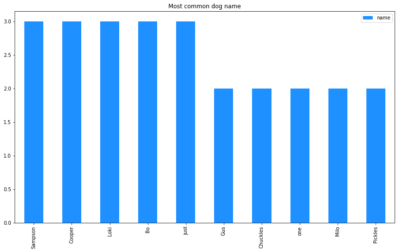

```python
# Most common dog name
twitter_archive_master['name'].value_counts().to_frame()[:10].plot(kind = 'bar',
                                                          title = "Most common dog name",
                                                          color= 'dodgerblue',figsize =(14,8))
```

### Most common dog stage that occur most during the rating

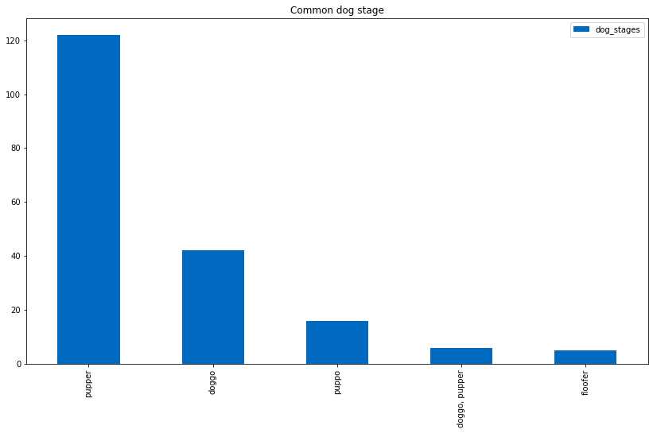

```python
# most common dog stage that occur most during the rating
twitter_archive_master['dog_stages'].value_counts().to_frame().plot(kind = 'bar',
                                                          title = "Common dog stage",
                                                          color= '#0069c0',figsize =(14,8))
```

### Top 3 dogs with the favorite retweet

```python
favorite_dog = twitter_archive_master.groupby('name', as_index= False)['favorite_count'].max()
favorite_dog = twitter_archive_master.nlargest(3,'favorite_count')
favorite_dog.set_index('name', inplace = True)
favorite_dog
```

| name | tweet_id | timestamp | source | text | expanded_urls | rating_numerator | rating_denominator | month | year | dog_stages | ... | p1_conf | p1_dog | p2 | p2_conf | p2_dog | p3 | p3_conf | p3_dog | retweet_count | favorite_count |
| --- | --- | --- | --- | --- | --- | --- | --- | --- | --- | --- | --- | --- | --- | --- | --- | --- | --- | --- | --- | --- | --- |
| Jamesy | 866450705531457537 | 2017-05-22 00:28:40+00:00 | Twitter for iPhone | This is Jamesy. He gives a kiss to every other... | https://twitter.com/dog_rates/status/866450705... | 13 | 10 | May | 2017 | pupper | ... | 0.905334 | True | boston bull | 0.078060 | True | pug | 0.001771 | True | 32883 | 106827 |
| Bo | 819004803107983360 | 2017-01-11 02:15:36+00:00 | Twitter for iPhone | This is Bo. He was a very good First Doggo. 14... | https://twitter.com/dog_rates/status/819004803... | 14 | 10 | January | 2017 | doggo | ... | 0.351308 | True | toy poodle | 0.271929 | True | tibetan terrier | 0.094759 | True | 42228 | 95450 |
| Sunny | 819006400881917954 | 2017-01-11 02:21:57+00:00 | Twitter for iPhone | This is Sunny. She was also a very good First ... | https://twitter.com/dog_rates/status/819006400... | 14 | 10 | January | 2017 | doggo | ... | 0.907083 | False | palace | 0.020089 | False | umbrella | 0.007850 | False | 21794 | 49960 |

3 rows × 23 columns

### Top dogs with the highest retweet

```python
# Dog with the highest retweet
retweeted_dog = twitter_archive_master.groupby('name', as_index= False)['retweet_count'].max()
retweeted_dog = twitter_archive_master.nlargest(1,'retweet_count')
retweeted_dog.set_index('name', inplace = True)
retweeted_dog
```

| name | tweet_id | timestamp | source | text | expanded_urls | rating_numerator | rating_denominator | month | year | dog_stages | ... | p1_conf | p1_dog | p2 | p2_conf | p2_dog | p3 | p3_conf | p3_dog | retweet_count | favorite_count |
| --- | --- | --- | --- | --- | --- | --- | --- | --- | --- | --- | --- | --- | --- | --- | --- | --- | --- | --- | --- | --- | --- |
| Bo | 819015337530290176 | 2017-01-11 02:57:27+00:00 | Twitter for iPhone | RT @dog_rates: This is Bo. He was a very good ... | https://twitter.com/dog_rates/status/819004803... | 14 | 10 | January | 2017 | doggo | ... | 0.351308 | True | toy poodle | 0.271929 | True | tibetan terrier | 0.094759 | True | 42228 | 0 |

1 rows × 23 columns

### Counting the number of rating that occured most

[figure not shown]

```python
#Counting the number of rating that occured most
dog_rating_count = twitter_archive_master['rating_numerator'].value_counts()[:5]

dog_rating_count.to_frame().plot(kind = 'bar',
                                    title = "Common dog stage",
                                         color= 'mediumslateblue',figsize =(14,8))
```

### Most common dog breed from prediction

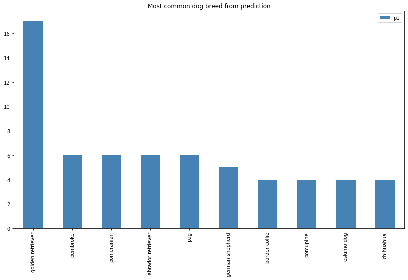

```python
twitter_archive_master['p1'].value_counts().to_frame()[:10].plot(kind = 'bar',
                                                          title = "Most common dog breed from prediction",
                                                          color= 'steelblue',figsize =(14,8))
```

### Source used for Rating

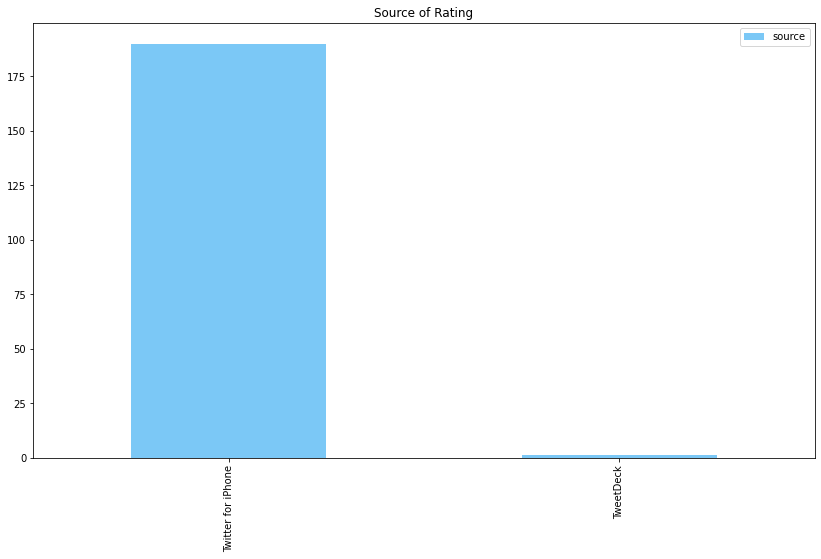

```python
twitter_archive_master['source'].value_counts().to_frame().plot(kind = 'bar',
                                                          title = "Source of Rating",
                                                          color= '#7bc8f6',figsize =(14,8))
```

### Correlation between favorite_count and retweet_count

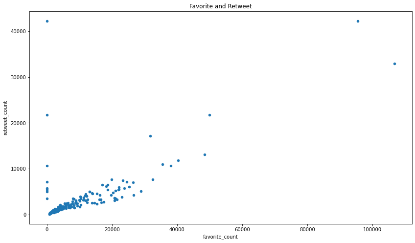

```python
#
twitter_archive_master.plot(x='favorite_count', y='retweet_count', kind='scatter', title = 'Favorite and Retweet',
                           figsize =(14,8));
```